# Raport - Repartitii discrete si continue

Probabilitati si Statistica

Hanghicel Razvan-Mihai Grupa 241

2023-01-28

### Introducere

Am creat o aplicatie in care se reprezinta 15 repartitii discrete si continue. Pentru fiecare repartitie se pot selecta parametrii care intra in definitia repartitiei si astfel se traseaza graficele pentru functia de densitate, functia de masa si functia de repartitie. Pentru fiecare repartitie putem adauga valori pentru a si b pentru a putea trasa grafic probabilitati de forma $P(X \le a)$ (reprezentata cu culoarea rosu), $P(X \ge b)$ (reprezentata cu culoarea verde) si $P(a \le X \le b)$ (reprezentata cu culoarea albastru)

### Aplicatia

Pentru a crea aplicatia am folosit librariile **shiny** si **ggplot** pentru a putea reprezenta graficele repartitiilor. In partea de **ui** am folosit un **selectInput** pentru a crea un dropdown menu in care poti selecta repartitia la care vrei sa ii vezi reprezentarile grafice. Apoi pentru fiecare repartitie am pus cate un **conditionalPanel** pentru a crea un template corespunzator fiecarei repartitii in care poti seta valori parametrilor specifici pentru fiecare repartitie. Apoi cu **textInput** o sa poti seta valorile parametrilor *a* si *b*. Am folosit **tabsetPanel** pentru a crea un navbar pentru a putea selecta ce tip de grafic sa fie reprezentat

```r
library(shiny)
library(ggplot2)
ui <- fluidPage(
  selectInput("distribution", "Select a Distribution:", c("Binomial", "Normal","Poisson", "Gamma", "Exponential", "Weibull", "Hypergeometric", "Log-normal", "Negative binomial", "Beta", "Fisher", "Cauchy", "Chy-Squared", "Laplace", "Pareto")),
  conditionalPanel(condition = "input.distribution == 'Binomial'",
                   textInput("size", "Size:", value = 10),
                   textInput("prob", "Probability:", value = 0.5)),
  conditionalPanel(condition = "input.distribution == 'Normal'",
                   textInput("mean", "Mean:", value = 0),
                   textInput("sd", "Standard Deviation:", value = 1)),
  conditionalPanel(condition = "input.distribution == 'Poisson'",
                   textInput("lambda", "Lambda:", value = 1)),
  conditionalPanel(condition = "input.distribution == 'Gamma'",
                   textInput("shape", "Shape:", value = 1),
                   textInput("scale", "Scale:", value = 1)),
  conditionalPanel(condition = "input.distribution == 'Exponential'",
                   textInput("rate", "Rate:", value = 1)),
  conditionalPanel(condition = "input.distribution == 'Weibull'",
                   textInput("shapeW", "Shape:", value = 1),
                   textInput("scaleW", "Scale:", value = 1)),
  conditionalPanel(condition = "input.distribution == 'Hypergeometric'",
                   textInput("m", "M:", value = 1),
                   textInput("n", "N:", value = 1),
                   textInput("k", "K:", value = 1)),
  conditionalPanel(condition = "input.distribution == 'Log-normal'",
                   textInput("ml", "MeanLog:", value = 1),
                   textInput("sl", "SdLog:", value = 1)),
  conditionalPanel(condition = "input.distribution == 'Negative binomial'",
                   textInput("s", "Size:", value = 1),
                   textInput("p", "Prob:", value = 1)),
  conditionalPanel(condition = "input.distribution == 'Beta'",
                   textInput("s1", "Shape1:", value = 1),
                   textInput("s2", "Shape2:", value = 1),
                   textInput("ncp", "Ncp:", value = 1)),

  conditionalPanel(condition = "input.distribution == 'Fisher'",
                   textInput("df1", "Df1:", value = 1),
                   textInput("df2", "Df2:", value = 1),
                   textInput("ncp", "Ncp:", value = 1)),

  conditionalPanel(condition = "input.distribution == 'Cauchy'",
                   textInput("l", "Location:", value = 1),
                   textInput("s", "Scale:", value = 1)),

  conditionalPanel(condition = "input.distribution == 'Chy-Squared'",
                   textInput("df", "Df:", value = 1),
                   textInput("ncp", "Ncp:", value = 1)),

  conditionalPanel(condition = "input.distribution == 'Laplace'",
                   textInput("mu", "Mu:", value = 1),
                   textInput("sigma", "Sigma:", value = 1)),

  conditionalPanel(condition = "input.distribution == 'Pareto'",
                   textInput("aP", "A:", value = 1),
                   textInput("bP", "B:", value = 1)),

  textInput("a","a:"),
  textInput("b","b:"),
  tabsetPanel(type = "tabs",
              tabPanel("Density Function", plotOutput("densityPlot")),
              tabPanel("Mass Function", plotOutput("massPlot")),
              tabPanel("Repartition Function", plotOutput("cdfPlot"))
  )
)
```

## Repartitii

### 1.Binomial

Density function: size = 10, prob = 0.5, a = 2, b = 4

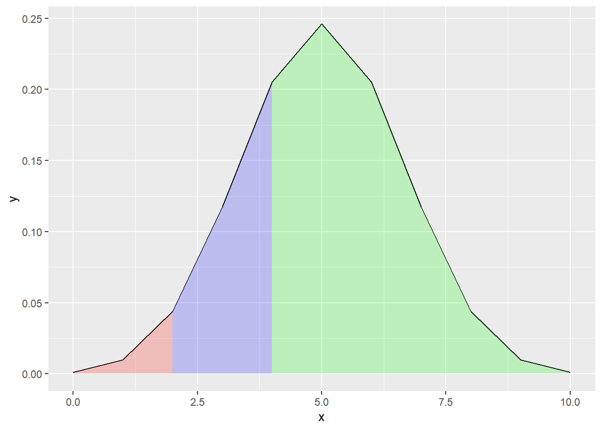

```r
library(ggplot2)
size <- 10
prob <- 0.5
x <- 0:size
y <- dbinom(x, size = size, prob = prob)
ggplot(data.frame(x, y), aes(x, y)) +
  geom_line() +
  geom_area(data = data.frame(x = x[x<=2], y = y[x<=2]), aes(x, y), fill = "red", alpha = 0.2) +
  geom_area(data = data.frame(x = x[x>=4], y = y[x>=4]), aes(x, y), fill = "green", alpha = 0.2) +
  geom_area(data = data.frame(x = x[x>=2 & x<=4], y = y[x>=2 & x<=4]), aes(x, y), fill = "blue", alpha = 0.2)
```

Mass function: size = 10, prob = 0.5, a = 2, b = 4

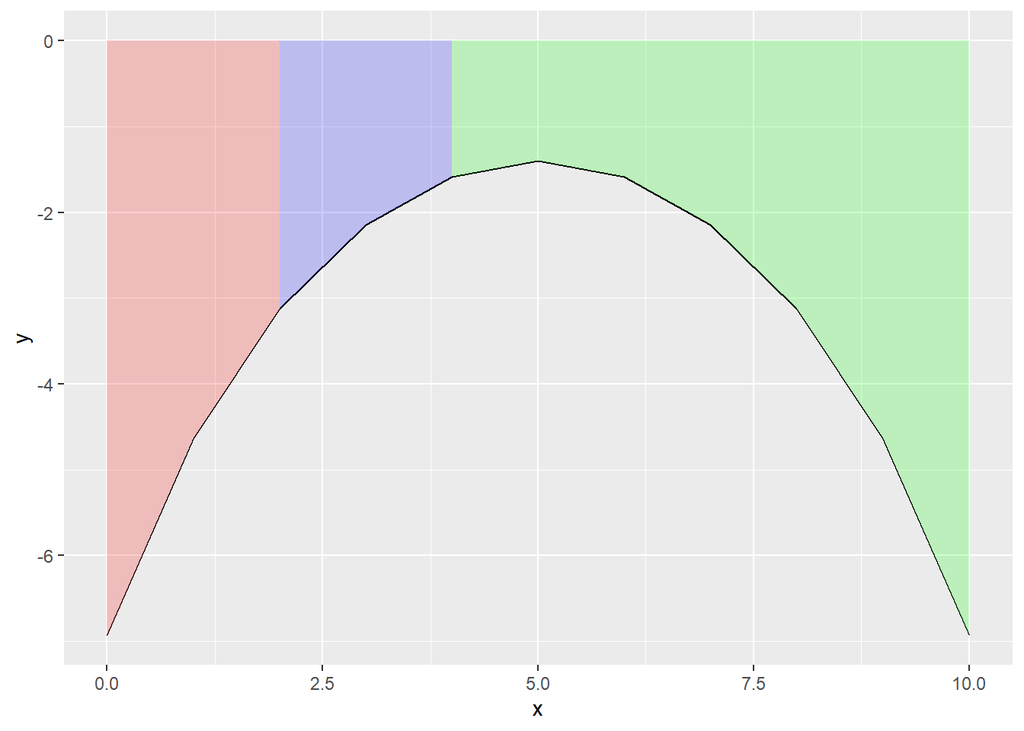

```r
library(ggplot2)
size <- 10
prob <- 0.5
x <- 0:size
y <- dbinom(x, size = size, prob = prob, log = TRUE)
ggplot(data.frame(x, y), aes(x, y)) +
  geom_line() +
  geom_area(data = data.frame(x = x[x<=2], y = y[x<=2]), aes(x, y), fill = "red", alpha = 0.2) +
  geom_area(data = data.frame(x = x[x>=4], y = y[x>=4]), aes(x, y), fill = "green", alpha = 0.2) +
  geom_area(data = data.frame(x = x[x>=2 & x<=4], y = y[x>=2 & x<=4]), aes(x, y), fill = "blue", alpha = 0.2)
```

Repartition function: size = 10, prob = 0.5, a = 2, b = 4

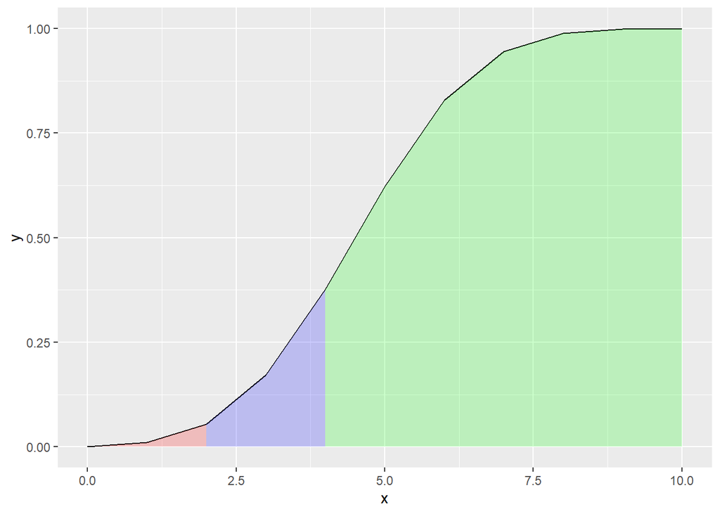

```r
library(ggplot2)
size <- 10
prob <- 0.5
x <- 0:size
y <- pbinom(x, size = size, prob = prob)
ggplot(data.frame(x, y), aes(x, y)) +
  geom_line() +
  geom_area(data = data.frame(x = x[x<=2], y = y[x<=2]), aes(x, y), fill = "red", alpha = 0.2) +
  geom_area(data = data.frame(x = x[x>=4], y = y[x>=4]), aes(x, y), fill = "green", alpha = 0.2) +
  geom_area(data = data.frame(x = x[x>=2 & x<=4], y = y[x>=2 & x<=4]), aes(x, y), fill = "blue", alpha = 0.2)
```

### 2.Normal

Density function: Mean = 0, Standard deviation = 1, a = -1, b = 1

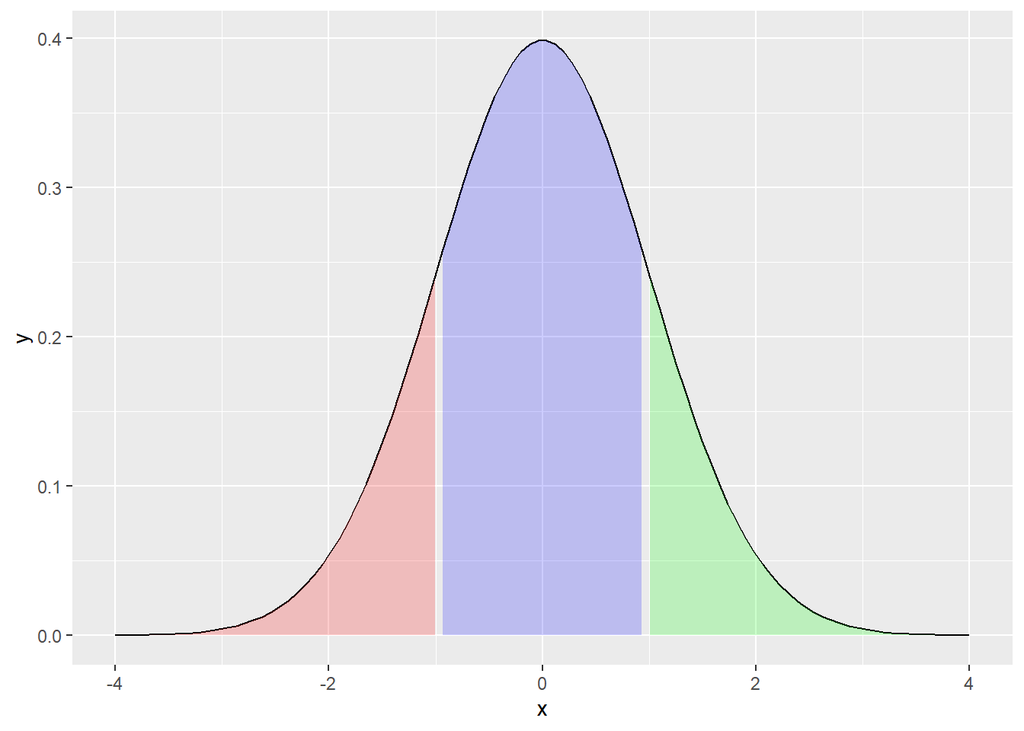

```r
library(ggplot2)
mean <- 0
      sd <- 1
      x <- seq(mean-4*sd, mean+4*sd, length.out = 100)
      y <- dnorm(x, mean = mean, sd = sd)
      ggplot(data.frame(x, y), aes(x, y)) +
        geom_line() +
        geom_area(data = data.frame(x = x[x<=-1], y = y[x<=-1]), aes(x, y), fill = "red", alpha = 0.2) +
        geom_area(data = data.frame(x = x[x>=1], y = y[x>=1]), aes(x, y), fill = "green", alpha = 0.2) +
        geom_area(data = data.frame(x = x[x>=-1 & x<=1], y = y[x>=-1 & x<=1]), aes(x, y), fill = "blue", alpha = 0.2)
```

Mass function: Mean = 0, Standard deviation = 1, a = -1, b = 1

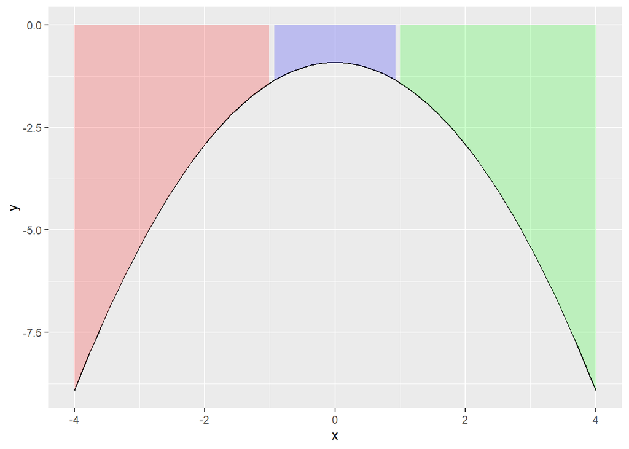

```r
library(ggplot2)
mean <- 0
      sd <- 1
      x <- seq(mean-4*sd, mean+4*sd, length.out = 100)
      y <- dnorm(x, mean = mean, sd = sd, log = TRUE)
      ggplot(data.frame(x, y), aes(x, y)) +
        geom_line() +
        geom_area(data = data.frame(x = x[x<=-1], y = y[x<=-1]), aes(x, y), fill = "red", alpha = 0.2) +
        geom_area(data = data.frame(x = x[x>=1], y = y[x>=1]), aes(x, y), fill = "green", alpha = 0.2) +
        geom_area(data = data.frame(x = x[x>=-1 & x<=1], y = y[x>=-1 & x<=1]), aes(x, y), fill = "blue", alpha = 0.2)
```

Repartition function: Mean = 0, Standard deviation = 1, a = -1, b = 1

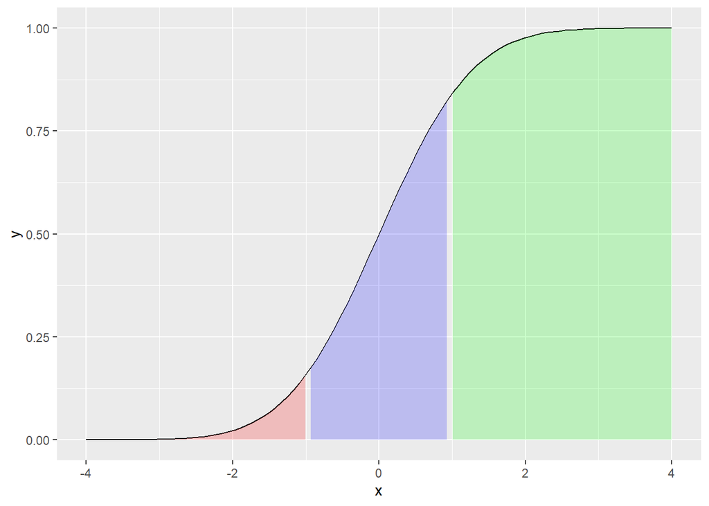

```r
library(ggplot2)
mean <- 0
      sd <- 1
      x <- seq(mean-4*sd, mean+4*sd, length.out = 100)
      y <- pnorm(x, mean = mean, sd = sd)
      ggplot(data.frame(x, y), aes(x, y)) +
        geom_line() +
        geom_area(data = data.frame(x = x[x<=-1], y = y[x<=-1]), aes(x, y), fill = "red", alpha = 0.2) +
        geom_area(data = data.frame(x = x[x>=1], y = y[x>=1]), aes(x, y), fill = "green", alpha = 0.2) +
        geom_area(data = data.frame(x = x[x>=-1 & x<=1], y = y[x>=-1 & x<=1]), aes(x, y), fill = "blue", alpha = 0.2)
```

### 3.Poisson

Density function: Lambda = 5, a = 2, b = 7

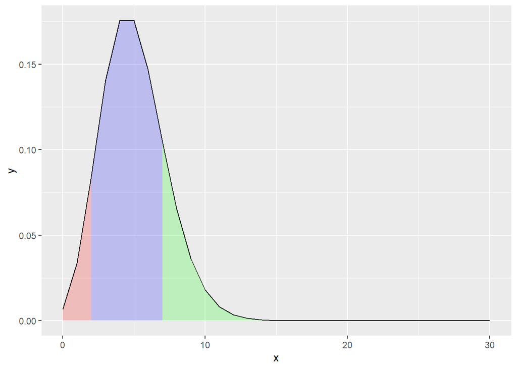

```r
library(ggplot2)
lambda <- 5
      x <- 0:30
      y <- dpois(x, lambda = lambda)
      ggplot(data.frame(x, y), aes(x, y)) +
        geom_line() +
        geom_area(data = data.frame(x = x[x<=2], y = y[x<=2]), aes(x, y), fill = "red", alpha = 0.2) +
        geom_area(data = data.frame(x = x[x>=7], y = y[x>=7]), aes(x, y), fill = "green", alpha = 0.2) +
        geom_area(data = data.frame(x = x[x>=2 & x<=7], y = y[x>=2 & x<=7]), aes(x, y), fill = "blue", alpha = 0.2)
```

Mass function: Lambda = 5, a = 2, b = 7

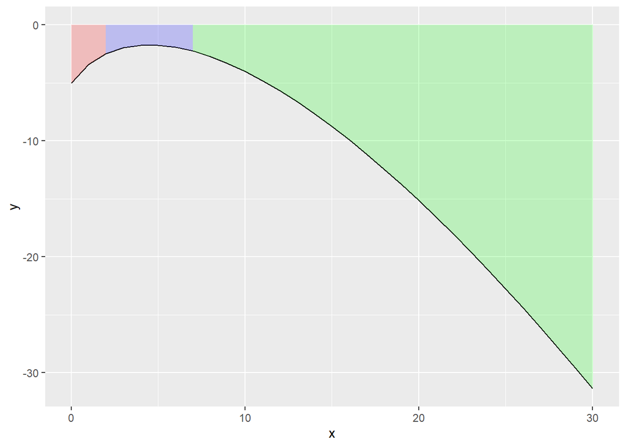

```r
library(ggplot2)
lambda <- 5
      x <- 0:30
      y <- dpois(x, lambda = lambda, log = TRUE)
      ggplot(data.frame(x, y), aes(x, y)) +
        geom_line() +
        geom_area(data = data.frame(x = x[x<=2], y = y[x<=2]), aes(x, y), fill = "red", alpha = 0.2) +
        geom_area(data = data.frame(x = x[x>=7], y = y[x>=7]), aes(x, y), fill = "green", alpha = 0.2) +
        geom_area(data = data.frame(x = x[x>=2 & x<=7], y = y[x>=2 & x<=7]), aes(x, y), fill = "blue", alpha = 0.2)
```

Repartition function: Lambda = 5, a = 2, b = 7

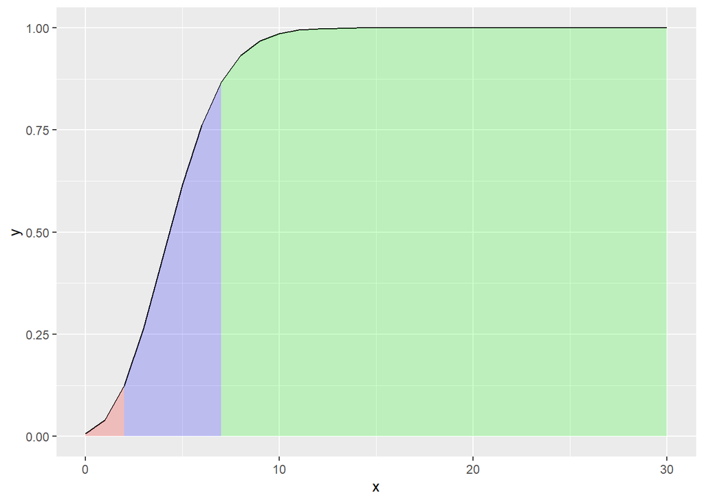

```r
library(ggplot2)
lambda <- 5
      x <- 0:30
      y <- ppois(x, lambda = lambda)
      ggplot(data.frame(x, y), aes(x, y)) +
        geom_line() +
        geom_area(data = data.frame(x = x[x<=2], y = y[x<=2]), aes(x, y), fill = "red", alpha = 0.2) +
        geom_area(data = data.frame(x = x[x>=7], y = y[x>=7]), aes(x, y), fill = "green", alpha = 0.2) +
        geom_area(data = data.frame(x = x[x>=2 & x<=7], y = y[x>=2 & x<=7]), aes(x, y), fill = "blue", alpha = 0.2)
```

### 4.Gamma

Density function: Shape = 5, Scale = 1, a = 2, b = 7

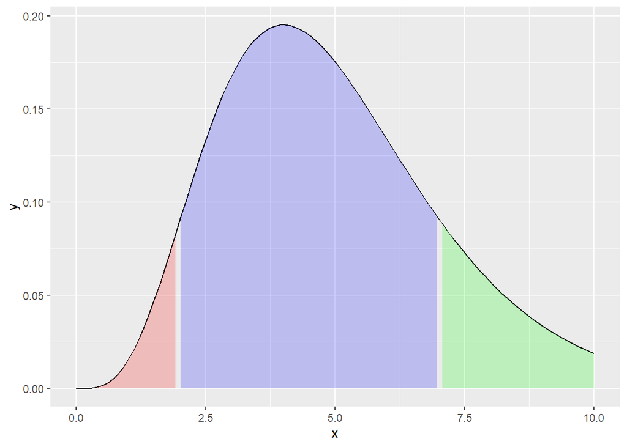

```r
library(ggplot2)
 shape <- 5
      scale <- 1
      x <- seq(0, shape*scale*2, length.out = 100)
      y <- dgamma(x, shape = shape, scale = scale)
      ggplot(data.frame(x, y), aes(x, y)) +
        geom_line() +
        geom_area(data = data.frame(x = x[x<=2], y = y[x<=2]), aes(x, y), fill = "red", alpha = 0.2) +
        geom_area(data = data.frame(x = x[x>=7], y = y[x>=7]), aes(x, y), fill = "green", alpha = 0.2) +
        geom_area(data = data.frame(x = x[x>=2 & x<=7], y = y[x>=2 & x<=7]), aes(x, y), fill = "blue", alpha = 0.2)
```

Mass function: Shape = 5, Scale = 1, a = 2, b = 7

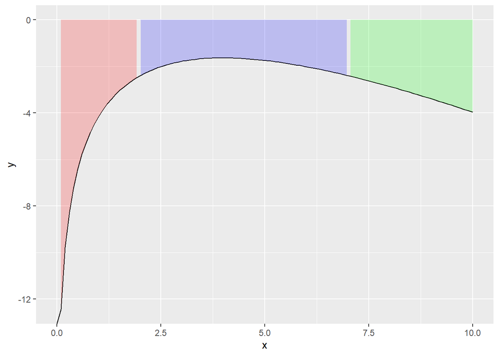

```r
library(ggplot2)
 shape <- 5
      scale <- 1
      x <- seq(0, shape*scale*2, length.out = 100)
      y <- dgamma(x, shape = shape, scale = scale, log = TRUE)
      ggplot(data.frame(x, y), aes(x, y)) +
        geom_line() +
        geom_area(data = data.frame(x = x[x<=2], y = y[x<=2]), aes(x, y), fill = "red", alpha = 0.2) +
        geom_area(data = data.frame(x = x[x>=7], y = y[x>=7]), aes(x, y), fill = "green", alpha = 0.2) +
        geom_area(data = data.frame(x = x[x>=2 & x<=7], y = y[x>=2 & x<=7]), aes(x, y), fill = "blue", alpha = 0.2)
```

Repartition function: Shape = 5, Scale = 1, a = 2, b = 7

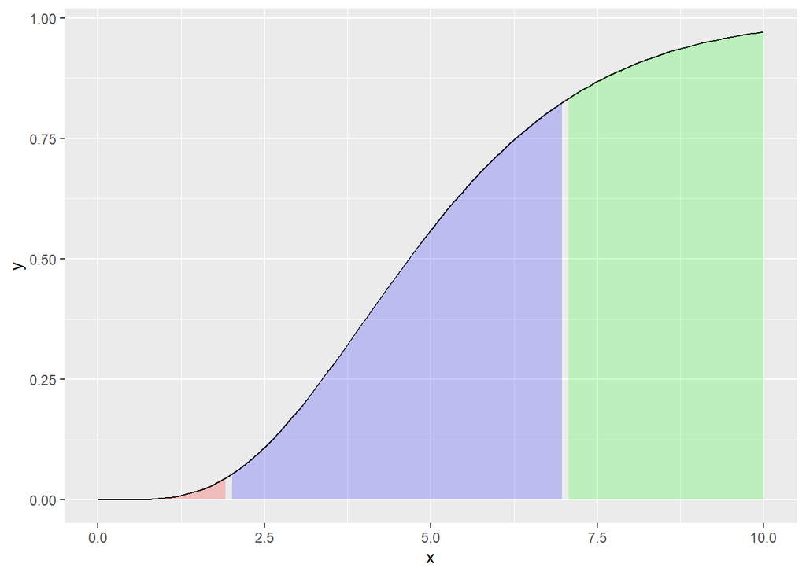

```r
library(ggplot2)
 shape <- 5
      scale <- 1
      x <- seq(0, shape*scale*2, length.out = 100)
      y <- pgamma(x, shape = shape, scale = scale)
      ggplot(data.frame(x, y), aes(x, y)) +
        geom_line() +
        geom_area(data = data.frame(x = x[x<=2], y = y[x<=2]), aes(x, y), fill = "red", alpha = 0.2) +
        geom_area(data = data.frame(x = x[x>=7], y = y[x>=7]), aes(x, y), fill = "green", alpha = 0.2) +
        geom_area(data = data.frame(x = x[x>=2 & x<=7], y = y[x>=2 & x<=7]), aes(x, y), fill = "blue", alpha = 0.2)
```

### 5.Exponential

Density function: Rate = 1, a = 0.5, b = 1

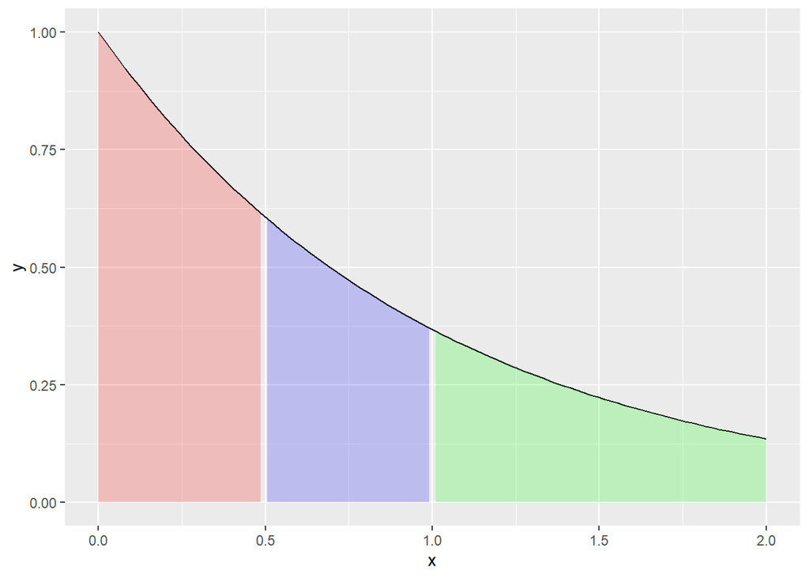

```r
library(ggplot2)
rate <- 1
      x <- seq(0, 2/rate, length.out = 100)
      y <- dexp(x, rate = rate)
      ggplot(data.frame(x, y), aes(x, y)) +
        geom_line() +
        geom_area(data = data.frame(x = x[x<=0.5], y = y[x<=0.5]), aes(x, y), fill = "red", alpha = 0.2) +
        geom_area(data = data.frame(x = x[x>=1], y = y[x>=1]), aes(x, y), fill = "green", alpha = 0.2) +
        geom_area(data = data.frame(x = x[x>=0.5 & x<=1], y = y[x>=0.5 & x<=1]), aes(x, y), fill = "blue", alpha = 0.2)
```

Mass function: Rate = 1, a = 0.5, b = 1

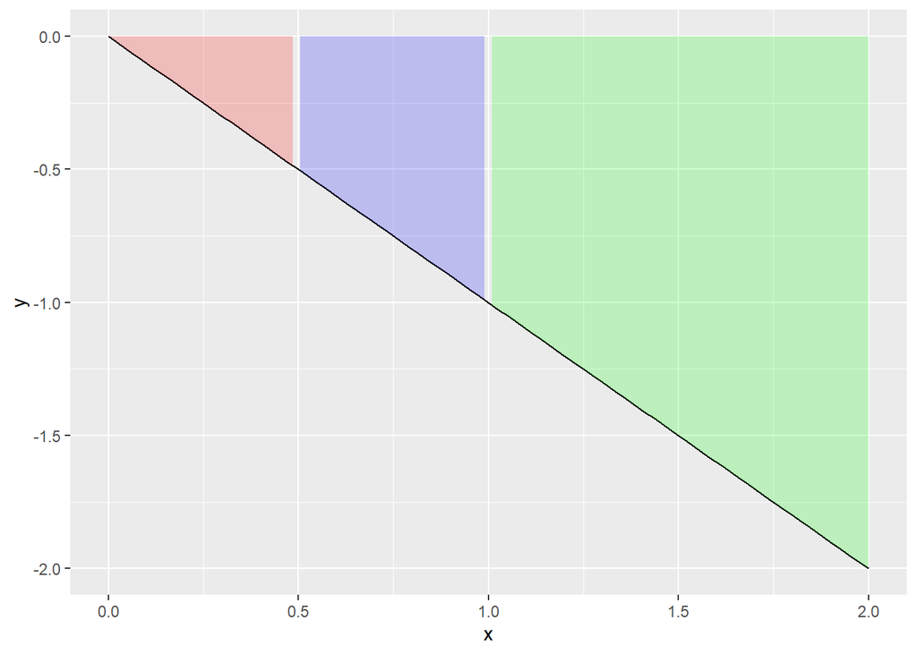

```r
library(ggplot2)
rate <- 1
      x <- seq(0, 2/rate, length.out = 100)
      y <- dexp(x, rate = rate, log = TRUE)
      ggplot(data.frame(x, y), aes(x, y)) +
        geom_line() +
        geom_area(data = data.frame(x = x[x<=0.5], y = y[x<=0.5]), aes(x, y), fill = "red", alpha = 0.2) +
        geom_area(data = data.frame(x = x[x>=1], y = y[x>=1]), aes(x, y), fill = "green", alpha = 0.2) +
        geom_area(data = data.frame(x = x[x>=0.5 & x<=1], y = y[x>=0.5 & x<=1]), aes(x, y), fill = "blue", alpha = 0.2)
```

Repartition function: Rate = 1, a = 0.5, b = 1

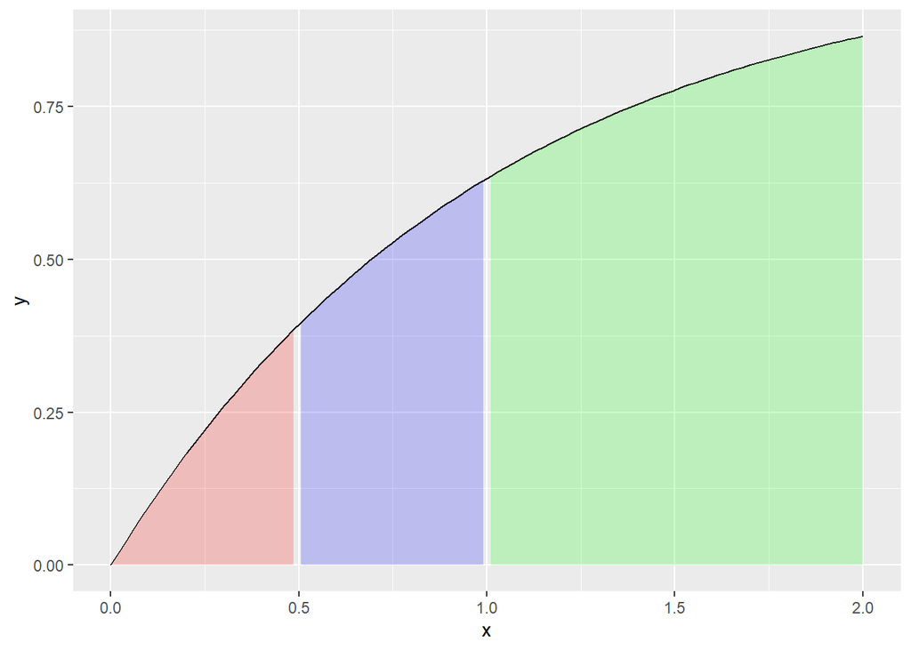

```r
library(ggplot2)
rate <- 1
      x <- seq(0, 2/rate, length.out = 100)
      y <- pexp(x, rate = rate)
      ggplot(data.frame(x, y), aes(x, y)) +
        geom_line() +
        geom_area(data = data.frame(x = x[x<=0.5], y = y[x<=0.5]), aes(x, y), fill = "red", alpha = 0.2) +
        geom_area(data = data.frame(x = x[x>=1], y = y[x>=1]), aes(x, y), fill = "green", alpha = 0.2) +
        geom_area(data = data.frame(x = x[x>=0.5 & x<=1], y = y[x>=0.5 & x<=1]), aes(x, y), fill = "blue", alpha = 0.2)
```

### 6.Weibull

Density function: Shape = 1, Scale = 1, a = 0.5, b = 1

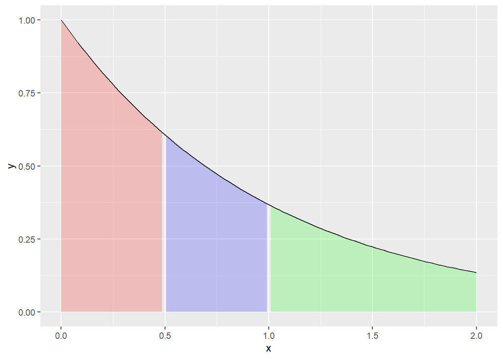

```r
library(ggplot2)
shape <- 1
      scale <- 1
      x <- seq(0, shape*scale*2, length.out = 100)
      y <- dweibull(x, shape = shape, scale = scale)
      ggplot(data.frame(x, y), aes(x, y)) +
        geom_line() +
        geom_area(data = data.frame(x = x[x<=0.5], y = y[x<=0.5]), aes(x, y), fill = "red", alpha = 0.2) +
        geom_area(data = data.frame(x = x[x>=1], y = y[x>=1]), aes(x, y), fill = "green", alpha = 0.2) +
        geom_area(data = data.frame(x = x[x>=0.5 & x<=1], y = y[x>=0.5 & x<=1]), aes(x, y), fill = "blue", alpha = 0.2)
```

Mass function: Shape = 1, Scale = 1, a = 0.5, b = 1

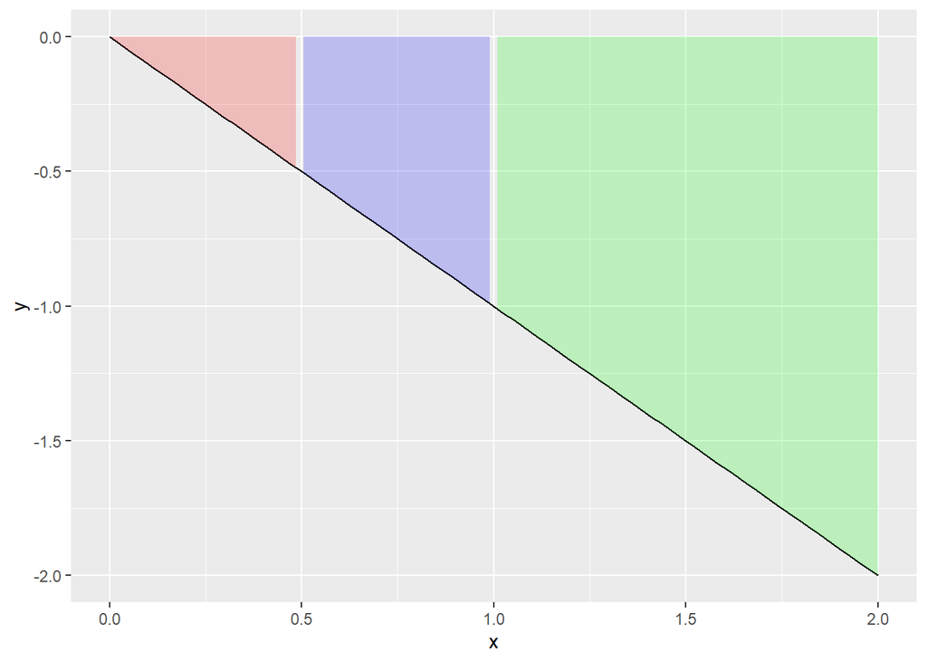

```r
library(ggplot2)
shape <- 1
      scale <- 1
      x <- seq(0, shape*scale*2, length.out = 100)
      y <- dweibull(x, shape = shape, scale = scale, log = TRUE)
      ggplot(data.frame(x, y), aes(x, y)) +
        geom_line() +
        geom_area(data = data.frame(x = x[x<=0.5], y = y[x<=0.5]), aes(x, y), fill = "red", alpha = 0.2) +
        geom_area(data = data.frame(x = x[x>=1], y = y[x>=1]), aes(x, y), fill = "green", alpha = 0.2) +
        geom_area(data = data.frame(x = x[x>=0.5 & x<=1], y = y[x>=0.5 & x<=1]), aes(x, y), fill = "blue", alpha = 0.2)
```

Repartition function: Shape = 1, Scale = 1, a = 0.5, b = 1

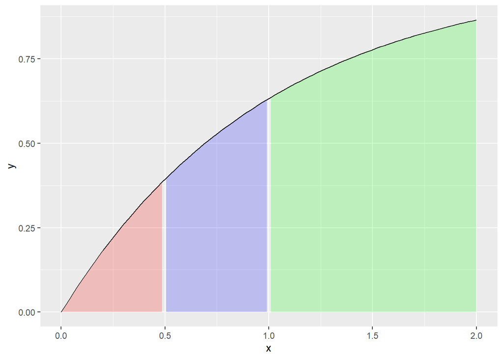

```r
library(ggplot2)
shape <- 1
      scale <- 1
      x <- seq(0, shape*scale*2, length.out = 100)
      y <- pweibull(x, shape = shape, scale = scale)
      ggplot(data.frame(x, y), aes(x, y)) +
        geom_line() +
        geom_area(data = data.frame(x = x[x<=0.5], y = y[x<=0.5]), aes(x, y), fill = "red", alpha = 0.2) +
        geom_area(data = data.frame(x = x[x>=1], y = y[x>=1]), aes(x, y), fill = "green", alpha = 0.2) +
        geom_area(data = data.frame(x = x[x>=0.5 & x<=1], y = y[x>=0.5 & x<=1]), aes(x, y), fill = "blue", alpha = 0.2)
```

### 7.Hypergeometric

Density function: M = 3, N = 4, K = 3, a = 1, b = 2

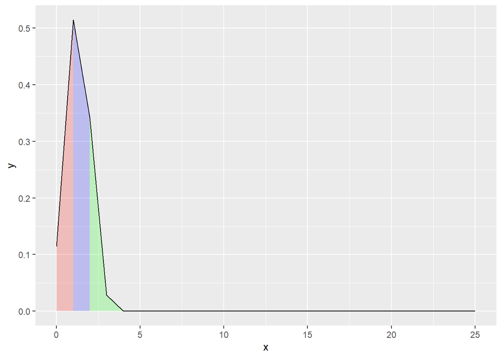

```r
library(ggplot2)
m <- 3
      n <- 4
      k <- 3
      x <- 0:25
      y <- dhyper(x, m = m, n = n, k = k)
      ggplot(data.frame(x, y), aes(x, y)) +
        geom_line() +
        geom_area(data = data.frame(x = x[x<=1], y = y[x<=1]), aes(x, y), fill = "red", alpha = 0.2) +
        geom_area(data = data.frame(x = x[x>=2], y = y[x>=2]), aes(x, y), fill = "green", alpha = 0.2) +
        geom_area(data = data.frame(x = x[x>=1 & x<=2], y = y[x>=1 & x<=2]), aes(x, y), fill = "blue", alpha = 0.2)
```

Mass function: M = 3, N = 4, K = 3, a = 1, b = 2

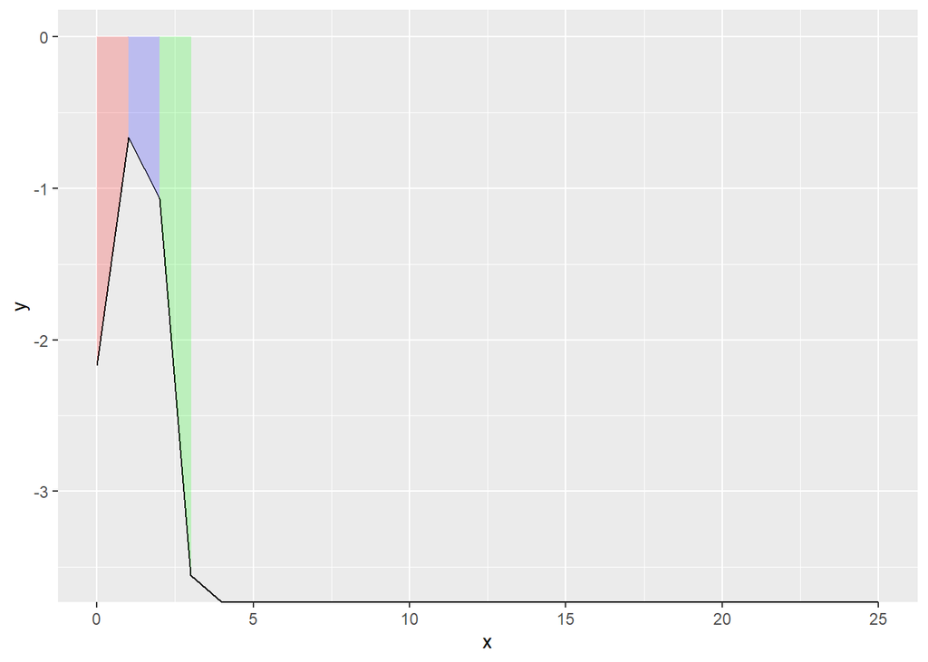

```r
library(ggplot2)
m <- 3
      n <- 4
      k <- 3
      x <- 0:25
      y <- dhyper(x, m = m, n = n, k = k, log = TRUE)
      ggplot(data.frame(x, y), aes(x, y)) +
        geom_line() +
        geom_area(data = data.frame(x = x[x<=1], y = y[x<=1]), aes(x, y), fill = "red", alpha = 0.2) +
        geom_area(data = data.frame(x = x[x>=2], y = y[x>=2]), aes(x, y), fill = "green", alpha = 0.2) +
        geom_area(data = data.frame(x = x[x>=1 & x<=2], y = y[x>=1 & x<=2]), aes(x, y), fill = "blue", alpha = 0.2)
```

Repartition function: M = 3, N = 4, K = 3, a = 1, b = 2

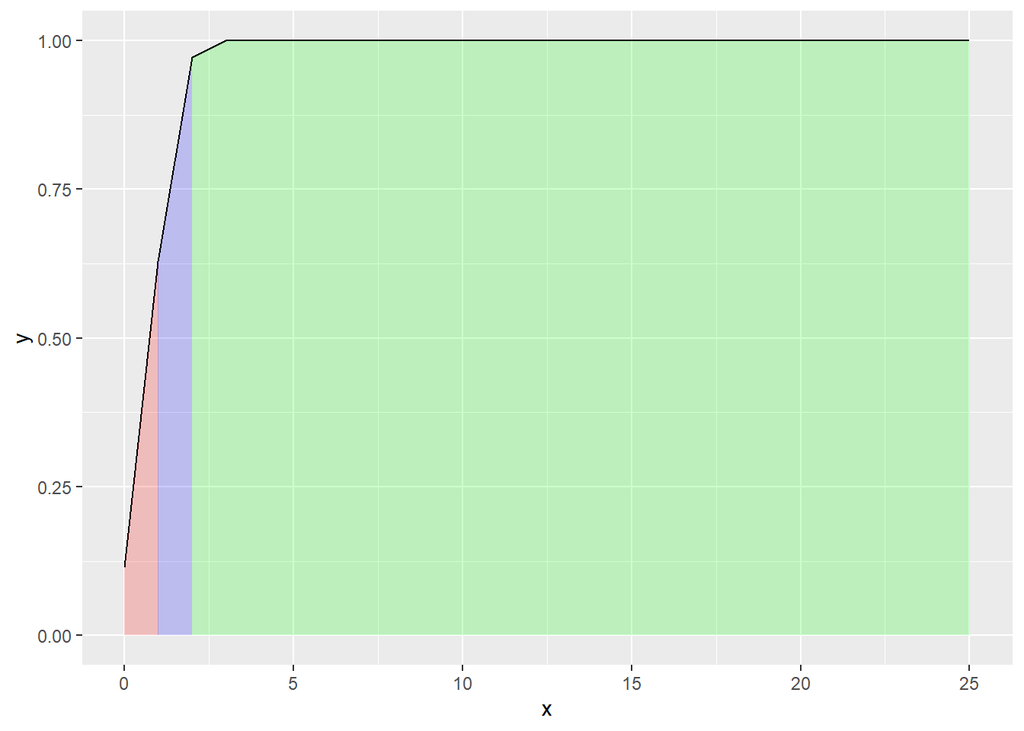

```r
library(ggplot2)
m <- 3
      n <- 4
      k <- 3
      x <- 0:25
      y <- phyper(x, m = m, n = n, k = k)
      ggplot(data.frame(x, y), aes(x, y)) +
        geom_line() +
        geom_area(data = data.frame(x = x[x<=1], y = y[x<=1]), aes(x, y), fill = "red", alpha = 0.2) +
        geom_area(data = data.frame(x = x[x>=2], y = y[x>=2]), aes(x, y), fill = "green", alpha = 0.2) +
        geom_area(data = data.frame(x = x[x>=1 & x<=2], y = y[x>=1 & x<=2]), aes(x, y), fill = "blue", alpha = 0.2)
```

### 8.Log-normal

Density function: Mean Log = 1, Standard Deviation Log = 1, a = 1, b = 3

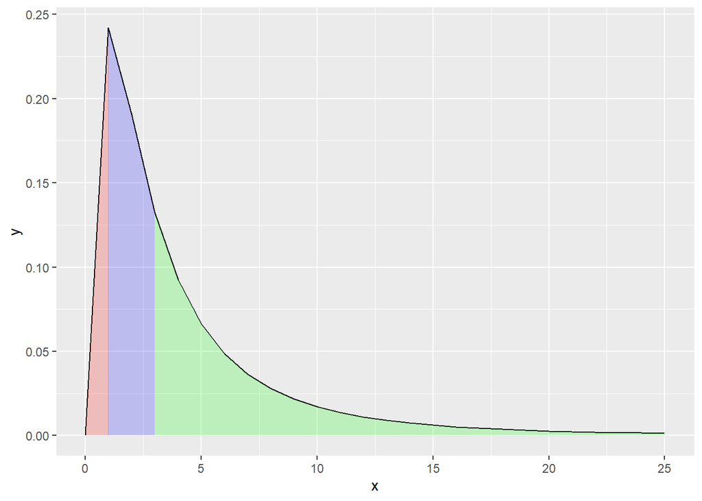

```r
library(ggplot2)
ml <- 1
      sl <- 1
      x <- 0:25
      y <- dlnorm(x, meanlog = ml, sdlog = sl)
      ggplot(data.frame(x, y), aes(x, y)) +
        geom_line() +
        geom_area(data = data.frame(x = x[x<=1], y = y[x<=1]), aes(x, y), fill = "red", alpha = 0.2) +
        geom_area(data = data.frame(x = x[x>=3], y = y[x>=3]), aes(x, y), fill = "green", alpha = 0.2) +
        geom_area(data = data.frame(x = x[x>=1 & x<=3], y = y[x>=1 & x<=3]), aes(x, y), fill = "blue", alpha = 0.2)
```

Mass function: Mean Log = 1, Standard Deviation Log = 1, a = 1, b = 3

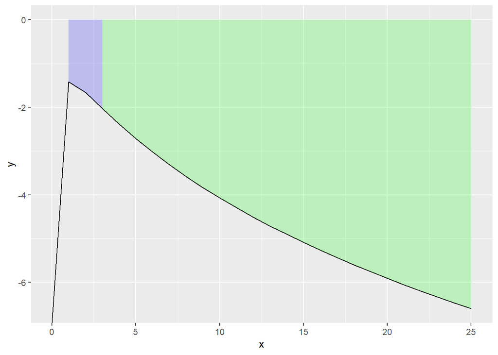

```r
library(ggplot2)
ml <- 1
      sl <- 1
      x <- 0:25
      y <- dlnorm(x, meanlog = ml, sdlog = sl, log = TRUE)
      ggplot(data.frame(x, y), aes(x, y)) +
        geom_line() +
        geom_area(data = data.frame(x = x[x<=1], y = y[x<=1]), aes(x, y), fill = "red", alpha = 0.2) +
        geom_area(data = data.frame(x = x[x>=3], y = y[x>=3]), aes(x, y), fill = "green", alpha = 0.2) +
        geom_area(data = data.frame(x = x[x>=1 & x<=3], y = y[x>=1 & x<=3]), aes(x, y), fill = "blue", alpha = 0.2)
```

Repartition function: Mean Log = 1, Standard Deviation Log = 1, a = 1, b = 3

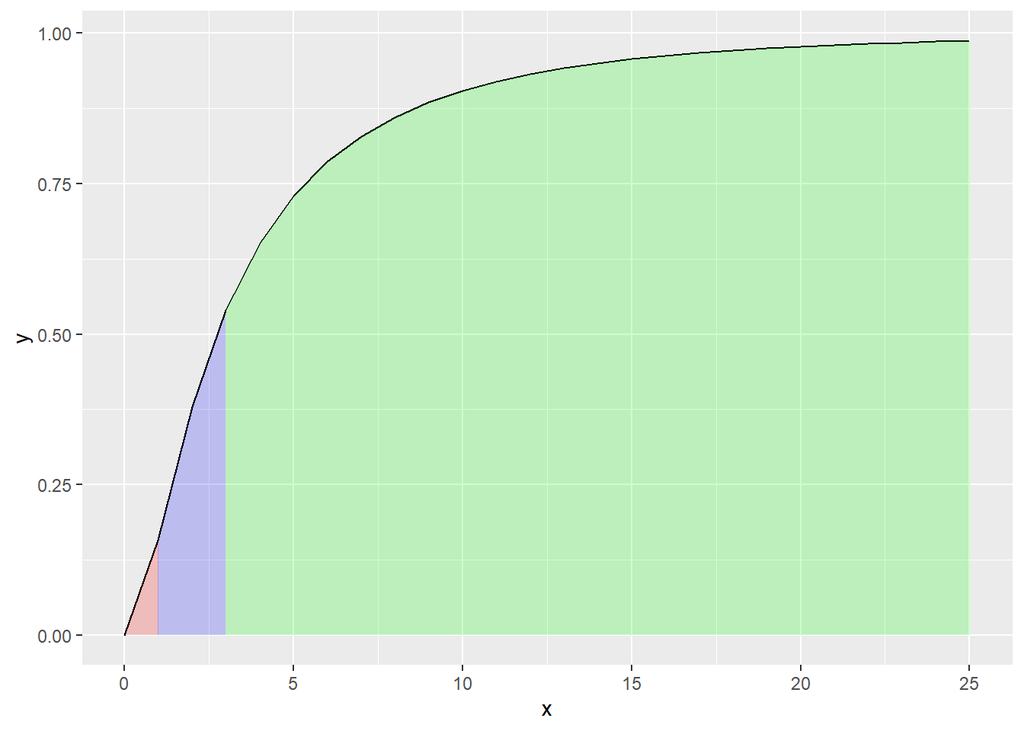

```r
library(ggplot2)
ml <- 1
      sl <- 1
      x <- 0:25
      y <- plnorm(x, meanlog = ml, sdlog = sl)
      ggplot(data.frame(x, y), aes(x, y)) +
        geom_line() +
        geom_area(data = data.frame(x = x[x<=1], y = y[x<=1]), aes(x, y), fill = "red", alpha = 0.2) +
        geom_area(data = data.frame(x = x[x>=3], y = y[x>=3]), aes(x, y), fill = "green", alpha = 0.2) +
        geom_area(data = data.frame(x = x[x>=1 & x<=3], y = y[x>=1 & x<=3]), aes(x, y), fill = "blue", alpha = 0.2)
```

### 9.Negative binomial

Density function: Size = 5, Prob = 0.5, a = 2, b = 5

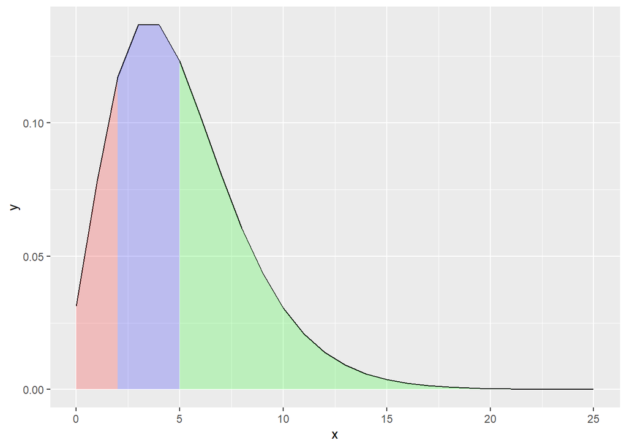

```r
library(ggplot2)

s <- 5
      p <- 0.5
      x <- 0:25
      y <- dnbinom(x, size = s, prob = p)
      ggplot(data.frame(x, y), aes(x, y)) +
        geom_line() +
        geom_area(data = data.frame(x = x[x<=2], y = y[x<=2]), aes(x, y), fill = "red", alpha = 0.2) +
        geom_area(data = data.frame(x = x[x>=5], y = y[x>=5]), aes(x, y), fill = "green", alpha = 0.2) +
        geom_area(data = data.frame(x = x[x>=2 & x<=5], y = y[x>=2 & x<=5]), aes(x, y), fill = "blue", alpha = 0.2)
```

Mass function: Size = 5, Prob = 0.5, a = 2, b = 5

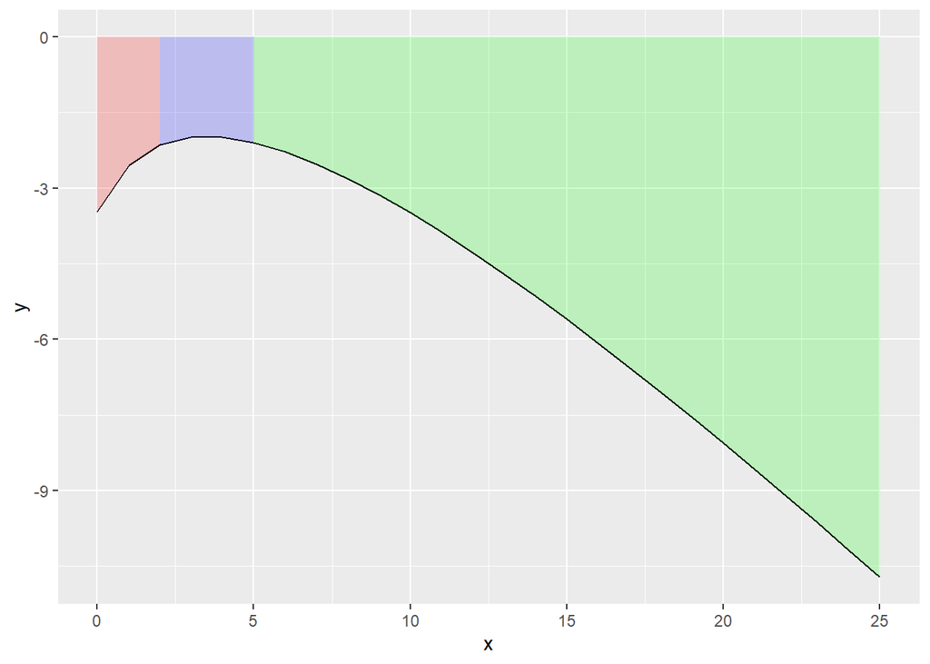

```r
library(ggplot2)

s <- 5
      p <- 0.5
      x <- 0:25
      y <- dnbinom(x, size = s, prob = p, log = TRUE)
      ggplot(data.frame(x, y), aes(x, y)) +
        geom_line() +
        geom_area(data = data.frame(x = x[x<=2], y = y[x<=2]), aes(x, y), fill = "red", alpha = 0.2) +
        geom_area(data = data.frame(x = x[x>=5], y = y[x>=5]), aes(x, y), fill = "green", alpha = 0.2) +
        geom_area(data = data.frame(x = x[x>=2 & x<=5], y = y[x>=2 & x<=5]), aes(x, y), fill = "blue", alpha = 0.2)
```

Repartition function: Size = 5, Prob = 0.5, a = 2, b = 5

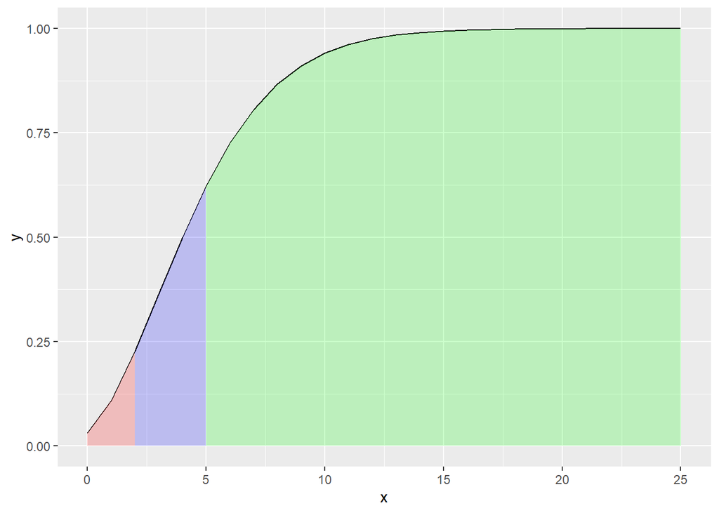

```r
library(ggplot2)

s <- 5
      p <- 0.5
      x <- 0:25
      y <- pnbinom(x, size = s, prob = p)
      ggplot(data.frame(x, y), aes(x, y)) +
        geom_line() +
        geom_area(data = data.frame(x = x[x<=2], y = y[x<=2]), aes(x, y), fill = "red", alpha = 0.2) +
        geom_area(data = data.frame(x = x[x>=5], y = y[x>=5]), aes(x, y), fill = "green", alpha = 0.2) +
        geom_area(data = data.frame(x = x[x>=2 & x<=5], y = y[x>=2 & x<=5]), aes(x, y), fill = "blue", alpha = 0.2)
```

### 10.Beta

Density function: Shape1 = 10, Shape2 = 1, Ncp = 1, a = 0, b = 1

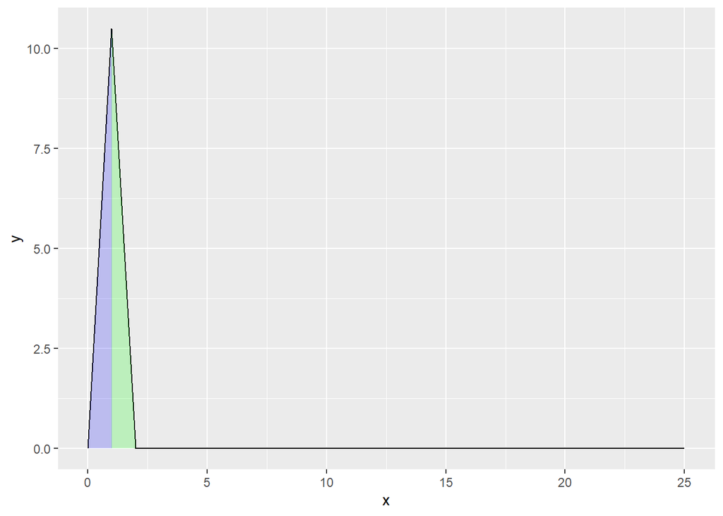

```r
library(ggplot2)
s1 <- 10
      s2 <- 1
      ncp <- 1
      x <- 0:25
      y <- dbeta(x, shape1 = s1, shape2 = s2, ncp = ncp)
      ggplot(data.frame(x, y), aes(x, y)) +
        geom_line() +
        geom_area(data = data.frame(x = x[x<=0], y = y[x<=0]), aes(x, y), fill = "red", alpha = 0.2) +
        geom_area(data = data.frame(x = x[x>=1], y = y[x>=1]), aes(x, y), fill = "green", alpha = 0.2) +
        geom_area(data = data.frame(x = x[x>=0 & x<=1], y = y[x>=0 & x<=1]), aes(x, y), fill = "blue", alpha = 0.2)
```

Mass function: Shape1 = 10, Shape2 = 1, Ncp = 1, a = 0, b = 1

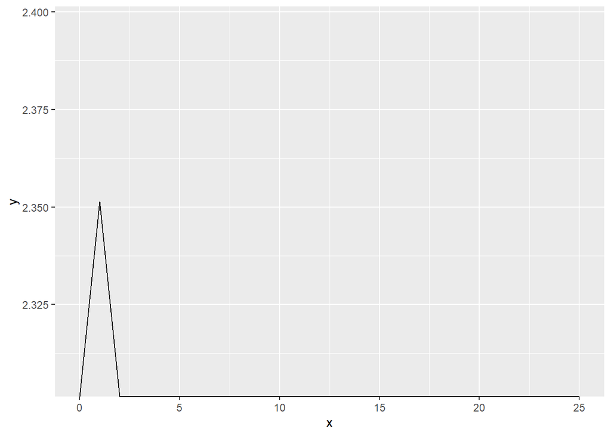

```r
library(ggplot2)
s1 <- 10
      s2 <- 1
      ncp <- 1
      x <- 0:25
      y <- dbeta(x, shape1 = s1, shape2 = s2, ncp = ncp, log = TRUE)
      ggplot(data.frame(x, y), aes(x, y)) +
        geom_line() +
        geom_area(data = data.frame(x = x[x<=0], y = y[x<=0]), aes(x, y), fill = "red", alpha = 0.2) +
        geom_area(data = data.frame(x = x[x>=1], y = y[x>=1]), aes(x, y), fill = "green", alpha = 0.2) +
        geom_area(data = data.frame(x = x[x>=0 & x<=1], y = y[x>=0 & x<=1]), aes(x, y), fill = "blue", alpha = 0.2)
```

Repartition function: Shape1 = 10, Shape2 = 1, Ncp = 1, a = 0, b = 1

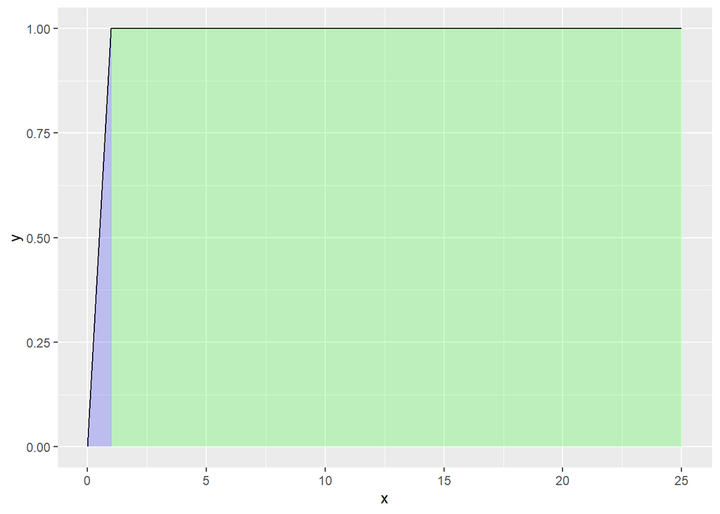

```r
library(ggplot2)
s1 <- 10
      s2 <- 1
      ncp <- 1
      x <- 0:25
      y <- pbeta(x, shape1 = s1, shape2 = s2, ncp = ncp)
      ggplot(data.frame(x, y), aes(x, y)) +
        geom_line() +
        geom_area(data = data.frame(x = x[x<=0], y = y[x<=0]), aes(x, y), fill = "red", alpha = 0.2) +
        geom_area(data = data.frame(x = x[x>=1], y = y[x>=1]), aes(x, y), fill = "green", alpha = 0.2) +
        geom_area(data = data.frame(x = x[x>=0 & x<=1], y = y[x>=0 & x<=1]), aes(x, y), fill = "blue", alpha = 0.2)
```